# Multi-cue recall (v3.4 - v3.6)

# Participants

- N = 69
- This combines the previous dataset (N = 40) with one collected on May 20 (N=29).

Note: Sanity checks moved to end.

# Proportion presentation time

The simplest test of rational memory: do people spend more time looking at the cue that they have a stronger memory of? This analysis only considers trials where both cues are seen.

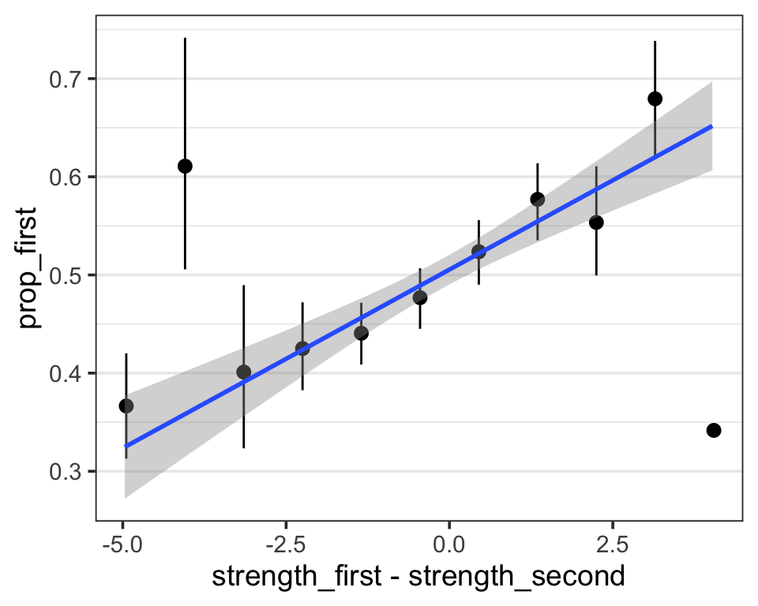

```r
X = multi %>%
    filter(n_pres >= 2)

X %>% ggplot(aes(strength_first - strength_second, prop_first)) +
    stat_summary_bin(fun.data=mean_cl_boot, bins=10) +
    geom_smooth(method='lm')
```

```r
X %>% lmer(prop_first ~ rel_strength + (rel_strength|wid), data=.) %>% summ
```

| Fixed Effects | Fixed Effects Est. | Fixed Effects S.E. | Fixed Effects t val. | Fixed Effects d.f. | Fixed Effects p |
| --- | --- | --- | --- | --- | --- |
| (Intercept) | 0.506 | 0.011 | 47.573 | 56.631 | 0.000 |
| rel_strength | 0.037 | 0.006 | 5.935 | 50.761 | 0.000 |

p values calculated using Satterthwaite d.f.

```r
X %>% lmer(prop_first ~ strength_first + strength_second + (strength_first + strength_second|wid), data=.) %>% summ
```

| Fixed Effects | Fixed Effects Est. | Fixed Effects S.E. | Fixed Effects t val. | Fixed Effects d.f. | Fixed Effects p |
| --- | --- | --- | --- | --- | --- |
| (Intercept) | 0.506 | 0.011 | 47.326 | 56.260 | 0.000 |
| strength_first | 0.037 | 0.008 | 4.352 | 47.465 | 0.000 |
| strength_second | -0.038 | 0.008 | -4.489 | 53.043 | 0.000 |

p values calculated using Satterthwaite d.f.

**Conclusion:** It seems like people are spending more time on the one they have a stronger memory for. But this result might not hold up to scrutiny….

## Problem: the last fixation

People remember the thing they look at last 94% of the time. Could that be driving the effect of relative strength on proportion presentation time?

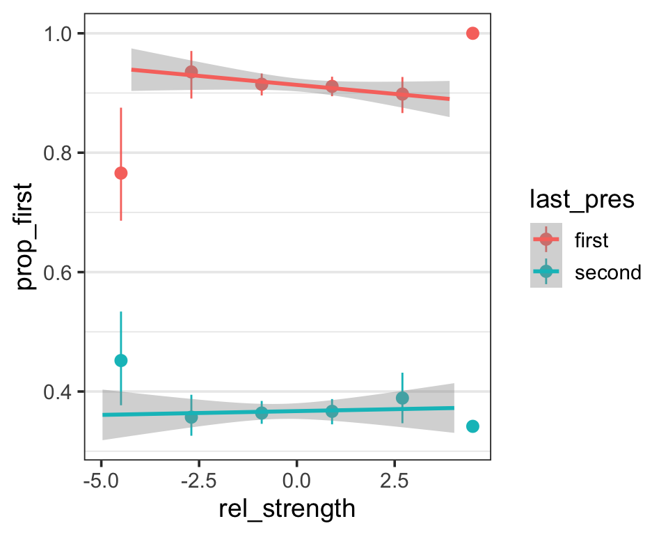

```r
multi = multi %>%
    mutate(last_pres = if_else(n_pres %% 2 == 1, "first", "second"))

multi %>%
    filter(n_pres <= 4) %>%
    ggplot(aes(rel_strength, prop_first, color=last_pres)) +
        stat_summary_bin(fun.data=mean_cl_boot, bins=5) +
        geom_smooth(method='lm')
```

```r
multi %>%
    filter(between(n_pres, 1, 4)) %>%
    lmer(prop_first ~ rel_strength * last_pres + (1 | wid), data=.) %>% summ
```

| Fixed Effects | Fixed Effects Est. | Fixed Effects S.E. | Fixed Effects t val. | Fixed Effects d.f. | Fixed Effects p |
| --- | --- | --- | --- | --- | --- |
| (Intercept) | 0.897 | 0.011 | 83.090 | 77.623 | 0.000 |
| rel_strength | -0.001 | 0.003 | -0.254 | 1088.973 | 0.799 |
| last_pressecond | -0.510 | 0.008 | -61.484 | 1128.151 | 0.000 |
| rel_strength:last_pressecond | 0.002 | 0.005 | 0.459 | 1099.786 | 0.647 |

p values calculated using Satterthwaite d.f.

When we control for which cue was presented last, the effect vanishes. Notably, this doesn’t occur in the optimal model simulations.

What’s going on here? Well, an obvious effect is that prop_first is higher on trials where the first cue is seen last (it has one more presentation than the other cue).

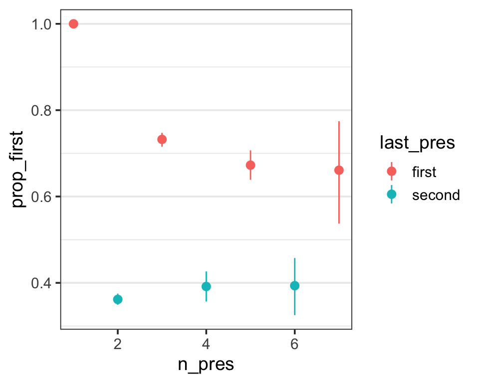

```r
multi %>%
    filter(n_pres < 8) %>%
    ggplot(aes(n_pres, prop_first, color=last_pres)) +
    stat_summary(fun.data=mean_cl_boot, bins=10)
```

A less obvious effect is that relative strength is higher for those trials.

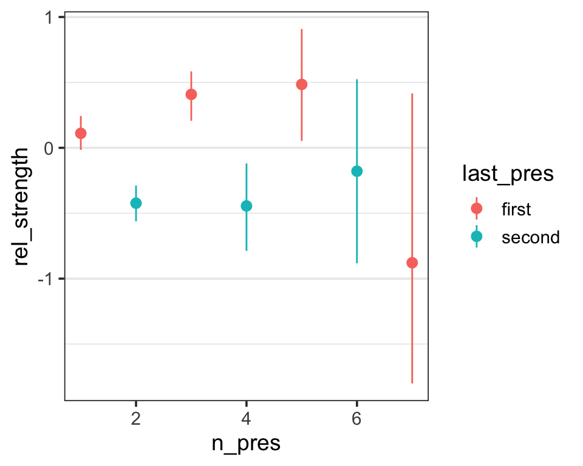

```r
multi %>%
    filter(n_pres < 8) %>%
    ggplot(aes(n_pres, rel_strength, color=last_pres)) +
    stat_summary(fun.data=mean_cl_boot, bins=10)
```

Putting the last two effects together, we get a correlation between rel_strength and prop_first based only on the target of the last presentation. Error bars are SEM. Trials are grouped by the number of presentations.

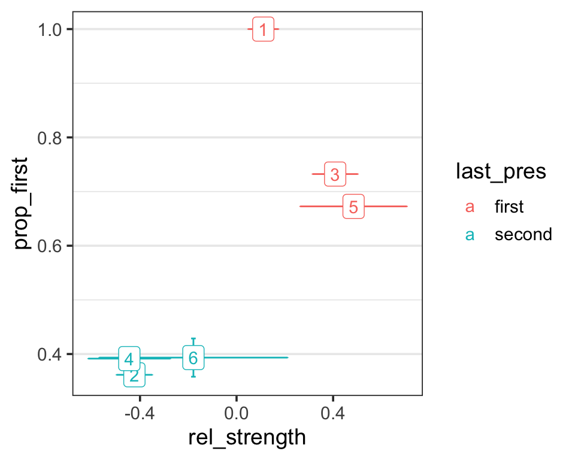

```r
multi %>%
    filter(between(n_pres, 1, 6)) %>%
    group_by(last_pres, n_pres) %>%
    summarise(across(c(rel_strength, prop_first), list(mean=mean, sd=~ sd(.x) / sqrt(length(.x))))) %>%
    ggplot(aes(rel_strength_mean, prop_first_mean, color=last_pres, label=n_pres)) +
    geom_errorbar(aes(ymin=prop_first_mean - prop_first_sd, ymax=prop_first_mean + prop_first_sd)) +
    geom_errorbarh(aes(xmin=rel_strength_mean - rel_strength_sd, xmax=rel_strength_mean + rel_strength_sd)) +
    labs(x="rel_strength", y="prop_first") +
    geom_label()
```

This looks bad. But all hope is not yet lost. Given that people have control over the number of presentations, it could be that the relationship between relative strength and the last presented cue is itself a sign of rational meta-memory. I was not able to get an effect nearly as strong as this in a random model with presentation times sampled from a Gamma distribution fit to the empirical distribution (I optimized the threshold and range of strengths to maximize the effect of relative strength on proportion first). However, I don’t think this effect alone is compelling evidence for rational meta-memory.

**Conclusion:** The proportion presentation time effect appears to be driven by the last presentation, which may or may not be itself related to rational meta-memory.

# First presentation duration

Given the complications with the total presentation duration, the duration of the first presentation is potentially a more reliable cue. The model makes a strong prediction here, and it probably isn’t confounded by the last presentation effect.

Consider only the trials with more than one presentation. Do participants switch away from the first image more quickly when they have a worse memory of it?

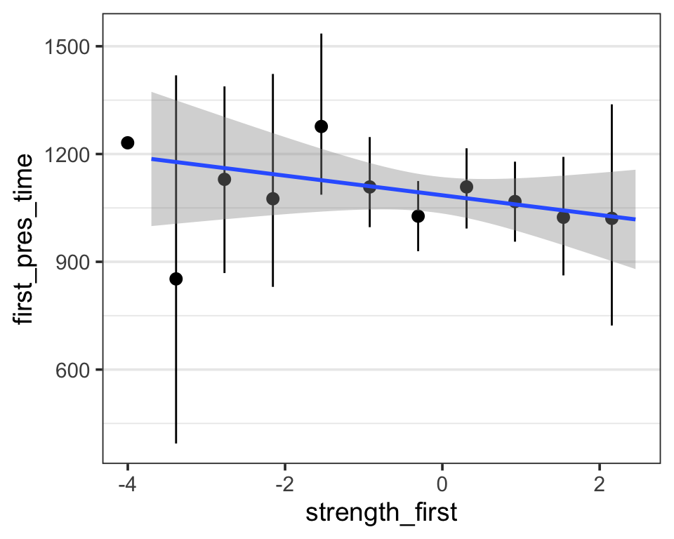

```r
X = multi %>%
    filter(n_pres > 1)

X %>% ggplot(aes(strength_first, first_pres_time)) +
    stat_summary_bin(fun.data=mean_cl_boot, bins=10) +
    geom_smooth(method='lm')
```

```r
X %>% lmer(first_pres_time ~ strength_first + (strength_first|wid), data=.) %>% summ
```

| Fixed Effects | Fixed Effects Est. | Fixed Effects S.E. | Fixed Effects t val. | Fixed Effects d.f. | Fixed Effects p |
| --- | --- | --- | --- | --- | --- |
| (Intercept) | 1309.409 | 89.287 | 14.665 | 44.387 | 0.000 |
| strength_first | 37.163 | 24.354 | 1.526 | 28.851 | 0.138 |

p values calculated using Satterthwaite d.f.

No sign of an effect here.

## Least memorable

Previously we saw some evidence of an effect for the least memorable cues. Does that hold in the new dataset? The linear model is for the new dataset only, for which this prediction is “pre-registered”.

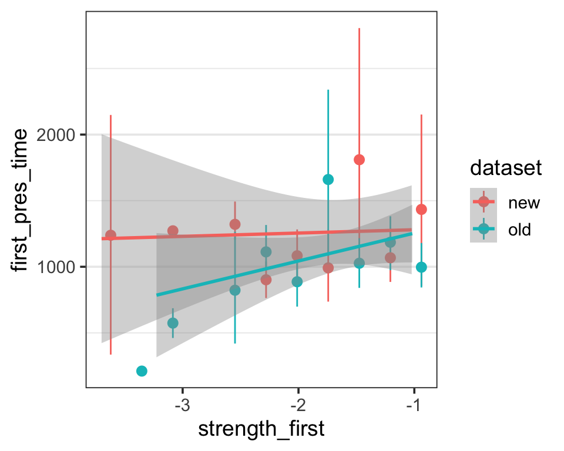

```r
X = multi %>%
    filter(n_pres > 1) %>%
    filter(strength_first < -1)

X %>% ggplot(aes(strength_first, first_pres_time, color=dataset)) +
    stat_summary_bin(fun.data=mean_cl_boot, bins=10) +
    geom_smooth(method='lm')
```

```r
X %>%
    filter(dataset == "new") %>%
    lmer(first_pres_time ~ strength_first + (strength_first|wid), data=.) %>% summ
```

| Fixed Effects | Fixed Effects Est. | Fixed Effects S.E. | Fixed Effects t val. | Fixed Effects d.f. | Fixed Effects p |
| --- | --- | --- | --- | --- | --- |
| (Intercept) | 1308.180 | 328.342 | 3.984 | 49.955 | 0.000 |
| strength_first | 26.024 | 183.464 | 0.142 | 41.316 | 0.888 |

p values calculated using Satterthwaite d.f.

```r
    # lmer(first_pres_time ~ strength_first + (strength_first|wid), data=.) %>% summ
```

No, it doesn’t. It appears that the previously found effect was spurious.

**Conclusion:** There is no sign of an effect on the first presentation duration.

# Second presentation duration

We can do a similar analysis for the second presentation duration. In this case, however, the duration may depend on the strength of both the first and second cues.

## Second-seen strength

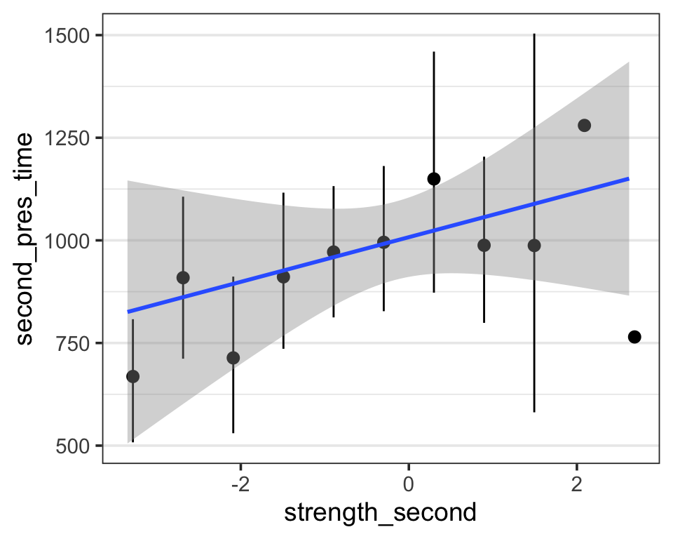

```r
X = multi %>%
    filter(n_pres > 2) %>%
    mutate(second_pres_time = map_dbl(presentation_times, 2, .default=NaN))

X %>% ggplot(aes(strength_second, second_pres_time)) +
    stat_summary_bin(fun.data=mean_cl_boot, bins=10) +
    geom_smooth(method='lm')
```

```r
X %>% lmer(second_pres_time ~ strength_second + (1|wid), data=.) %>% summ
```

| Fixed Effects | Fixed Effects Est. | Fixed Effects S.E. | Fixed Effects t val. | Fixed Effects d.f. | Fixed Effects p |
| --- | --- | --- | --- | --- | --- |
| (Intercept) | 1109.604 | 92.780 | 11.960 | 47.052 | 0.000 |
| strength_second | 43.487 | 42.222 | 1.030 | 348.678 | 0.304 |

p values calculated using Satterthwaite d.f.

There might be something here, but it’s very noisy.

## First-seen strength

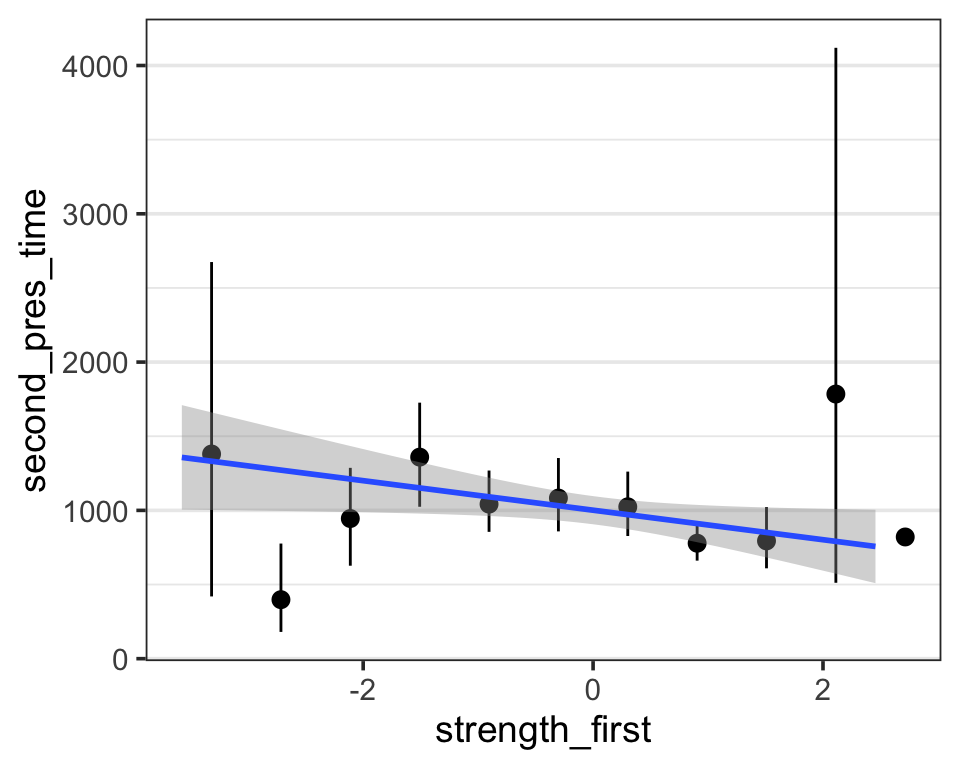

```r
X %>% ggplot(aes(strength_first, second_pres_time)) +
    stat_summary_bin(fun.data=mean_cl_boot, bins=10) +
    geom_smooth(method='lm')
```

```r
X %>% lmer(second_pres_time ~ strength_first + (strength_first|wid), data=.) %>% summ
```

| Fixed Effects | Fixed Effects Est. | Fixed Effects S.E. | Fixed Effects t val. | Fixed Effects d.f. | Fixed Effects p |
| --- | --- | --- | --- | --- | --- |
| (Intercept) | 1105.621 | 92.543 | 11.947 | 44.883 | 0.000 |
| strength_first | -72.914 | 54.190 | -1.346 | 24.861 | 0.191 |

p values calculated using Satterthwaite d.f.

Again, this is in the right direction, but it’s noisy, and not significant when we take into account random effects.

## Relative strength (first - second)

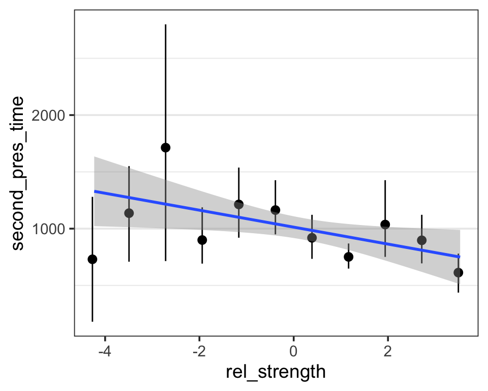

```r
X %>% ggplot(aes(rel_strength, second_pres_time)) +
    stat_summary_bin(fun.data=mean_cl_boot, bins=10) +
    geom_smooth(method='lm')
```

```r
X %>% lmer(second_pres_time ~ rel_strength + (rel_strength|wid), data=.) %>% summ
```

| Fixed Effects | Fixed Effects Est. | Fixed Effects S.E. | Fixed Effects t val. | Fixed Effects d.f. | Fixed Effects p |
| --- | --- | --- | --- | --- | --- |
| (Intercept) | 1116.328 | 95.010 | 11.750 | 43.342 | 0.000 |
| rel_strength | -69.369 | 32.506 | -2.134 | 30.950 | 0.041 |

p values calculated using Satterthwaite d.f.

A significant positive result!

**Conclusion:** There is weak evidence of rationality in the decision to switch *back* to the first item.

# Discussion

I think it is likely that people are showing some kind of rational behavior here. But, I don’t think the current results are sufficiently compelling (even if we had a larger N and smaller p’s).

Rather than trying to further optimize this paradigm, I think we should take a step back and consider more substantial changes to the paradigm. Two ideas come to mind.

**Trinary choice.** The effect of relative strength should be significantly stronger here. It also makes new analyses possible, for example, the fourth presented cue as a function of the difference in strength of the first two cue. Unfortunately, this would make dynamic programming infeasible so we’d have to invest some time figuring out how to approximate the optimal policy.

**Foraging.** In the opposite direction, we could try a task in which people only see one cue and the critical behavior is giving up. Something like this: you have a short amount of time to recall as many targets as you can. Each trial ends when you give a response (which can be empty). You are thus incentivized to identify cues that you won’t be able to recall quickly so that you can move on without wasting time. Arguably, deciding to give up on remembering something is more naturalistic than deciding which of two things to remember. Thus it’s possible that participants will perform better on this task. The modeling is a bit trickier here due to the opportunity cost issue, but I think it could be addressed by solving for different costs and identifying the cost that optimizes total performance (I think it would be equal to the average reward rate.)

**Strategy selection.** A similar idea (that avoids the opportunity cost issue) is to let participants choose between two strategies to respond on each trial. This would be similar to Lynne Reder’s task where people see a pair of numbers and decide whether to do the addition or recall the answer from memory. The simplest version of this would be to have a time penalty for incorrect responses. The “alternative strategy” is just giving up and taking the penalty. It might be more compelling if the alternative strategy actually produced the target, but I can’t think of a way to do this that wouldn’t give participants an opportunity for additional learning.

# Sanity and data-quality checks

## Probability of remembering first word

As a sanity check, we first ask if our memory strength index predicts participants choices about which image to recall. We operationalize memory strength as the within-participant Z-scored, mean-log 2AFC RT (that’s a mouthful!)

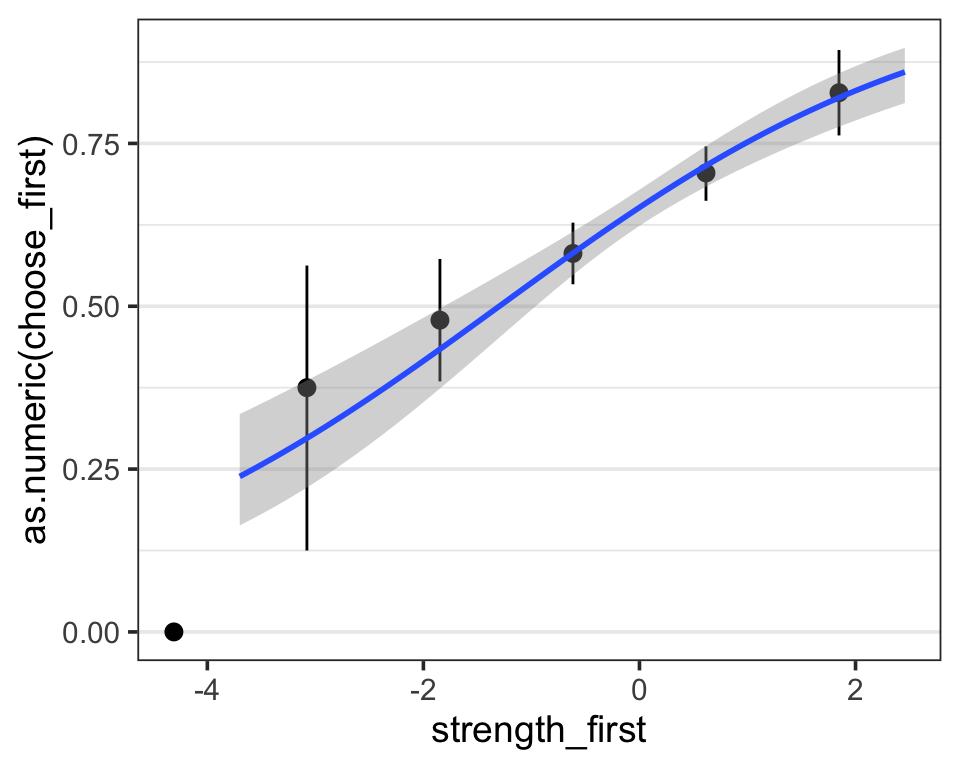

```r
multi %>% ggplot(aes(strength_first, as.numeric(choose_first))) +
    stat_summary_bin(fun.data=mean_cl_boot, bins=5) +
    geom_smooth(method = "glm", method.args = list(family = "binomial"), formula=y~x)
```

```r
lmer(choose_first ~ strength_first + (strength_first|wid), data=multi) %>% summ
```

| Fixed Effects | Fixed Effects Est. | Fixed Effects S.E. | Fixed Effects t val. | Fixed Effects d.f. | Fixed Effects p |
| --- | --- | --- | --- | --- | --- |
| (Intercept) | 0.645 | 0.022 | 29.218 | 66.009 | 0.000 |
| strength_first | 0.107 | 0.014 | 7.611 | 65.087 | 0.000 |

p values calculated using Satterthwaite d.f.

Note: unless otherwise stated, all regression tables are maximal linear mixed effects models (i.e. random slopes and intercepts). Plotted regression lines are plain old OLS.

We can also look at the difference between first and second, and how each strength contributed independently. Here, we only look at trials with at least two presentations (so that there is a second-seen cue).

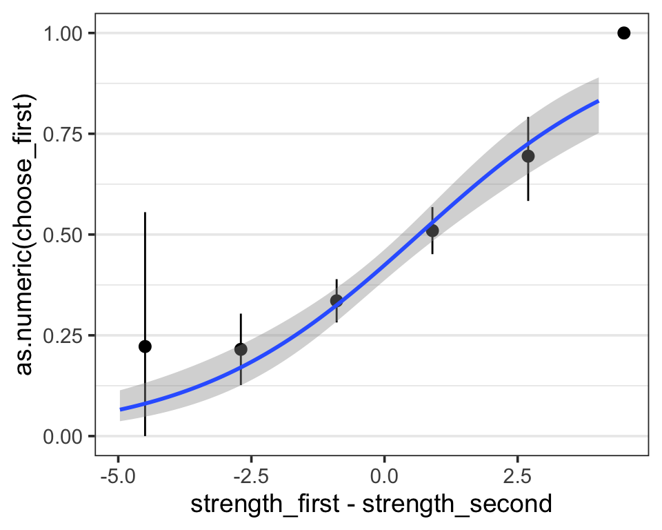

```r
X = multi %>%
    filter(n_pres >= 2)

X %>% ggplot(aes(strength_first - strength_second, as.numeric(choose_first))) +
    stat_summary_bin(fun.data=mean_cl_boot, bins=5) +
    geom_smooth(method = "glm", method.args = list(family = "binomial"), formula=y~x)
```

```r
lmer(choose_first ~ rel_strength + (rel_strength|wid), data=X) %>% summ
```

| Fixed Effects | Fixed Effects Est. | Fixed Effects S.E. | Fixed Effects t val. | Fixed Effects d.f. | Fixed Effects p |
| --- | --- | --- | --- | --- | --- |
| (Intercept) | 0.416 | 0.023 | 17.967 | 42.445 | 0.000 |
| rel_strength | 0.096 | 0.013 | 7.372 | 77.050 | 0.000 |

p values calculated using Satterthwaite d.f.

```r
lmer(choose_first ~ strength_first + strength_second + (strength_first + strength_second |wid), data=X) %>% summ
```

| Fixed Effects | Fixed Effects Est. | Fixed Effects S.E. | Fixed Effects t val. | Fixed Effects d.f. | Fixed Effects p |
| --- | --- | --- | --- | --- | --- |
| (Intercept) | 0.416 | 0.023 | 17.734 | 41.500 | 0.000 |
| strength_first | 0.092 | 0.018 | 5.089 | 110.527 | 0.000 |
| strength_second | -0.102 | 0.020 | -5.175 | 56.480 | 0.000 |

p values calculated using Satterthwaite d.f.

## Number of presentations

Many trials have one presentation. The zero-presentation trials are mostly from two uncooperative (or confused) participants. Importantly we get a decent proportion of trials where both items are seen.

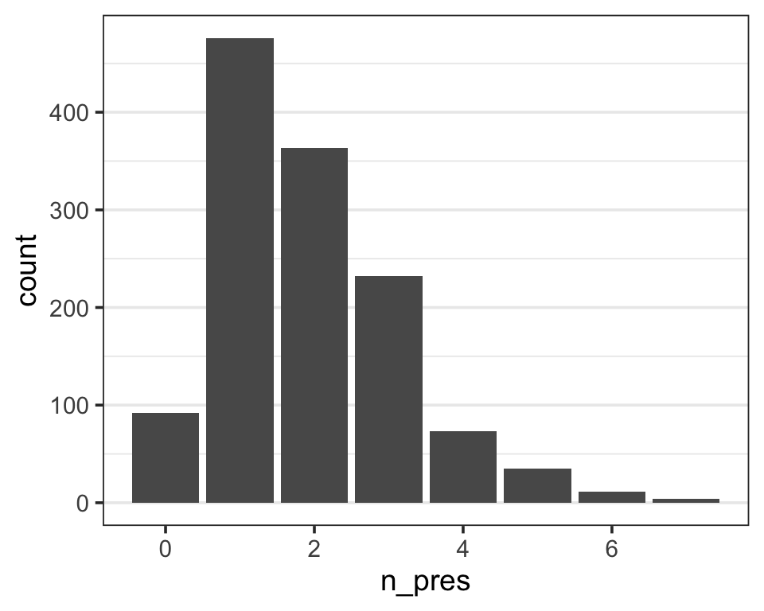

```r
multi %>% filter(n_pres <= 7) %>% ggplot(aes(n_pres)) +
    geom_bar()
```

Both cues are seen (n_pres ≥ 2) on 57% of trials.

**Conclusion:** We have a reliable measurement of memory strength (it predicts which target people remember) and we get enough switching to analyze that behavior.

# AFC correlations

How reliable are the AFC measures?

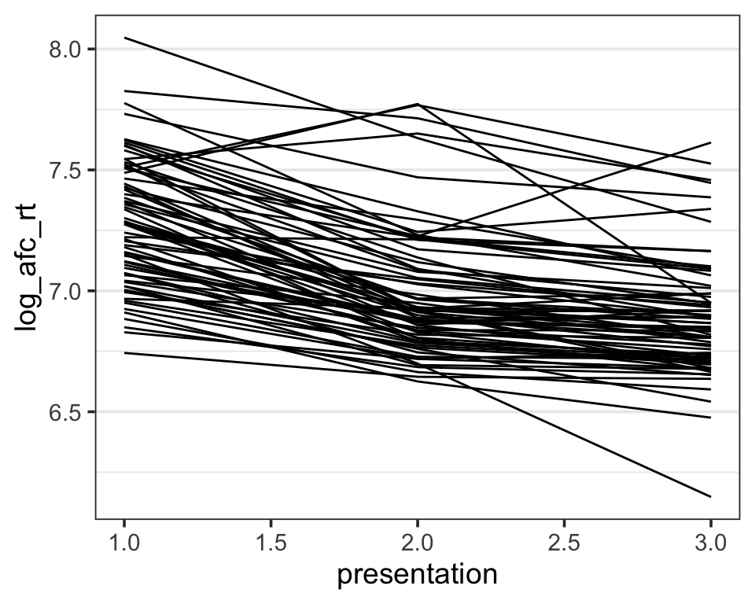

```r
afc %>% ggplot(aes(presentation, log_afc_rt, group=wid)) +
    stat_summary(fun=mean, geom="line", size=.5)
```

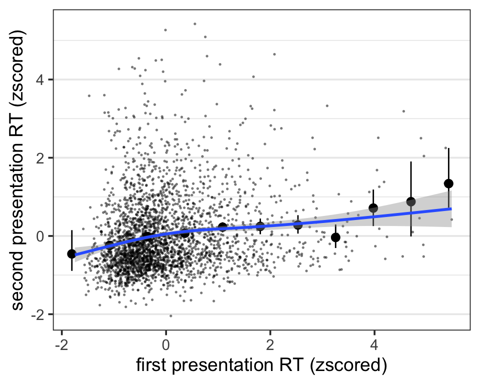

```r
X = afc %>%
    group_by(wid, presentation) %>%
    mutate(rt_z = scale(rt)) %>%
    select(wid, word, rt_z, presentation) %>%
    pivot_wider(names_from=presentation, values_from=rt_z, names_prefix="rt_z") %>%
    ungroup()

X %>% ggplot(aes(rt_z1, rt_z2)) +
    geom_point(size=.3, alpha=.4) +
    stat_summary_bin(fun.data=mean_cl_boot, bins=10) +
    geom_smooth() +
    labs(x="first presentation RT (zscored)", y="second presentation RT (zscored)")
```

```r
X %>% lmer(rt_z2 ~ rt_z1 + (rt_z1 + 0|wid), data=.) %>% summ
```

| Fixed Effects | Fixed Effects Est. | Fixed Effects S.E. | Fixed Effects t val. | Fixed Effects d.f. | Fixed Effects p |
| --- | --- | --- | --- | --- | --- |
| (Intercept) | -0.001 | 0.019 | -0.039 | 2658.999 | 0.969 |
| rt_z1 | 0.160 | 0.019 | 8.305 | 68.999 | 0.000 |

p values calculated using Satterthwaite d.f.

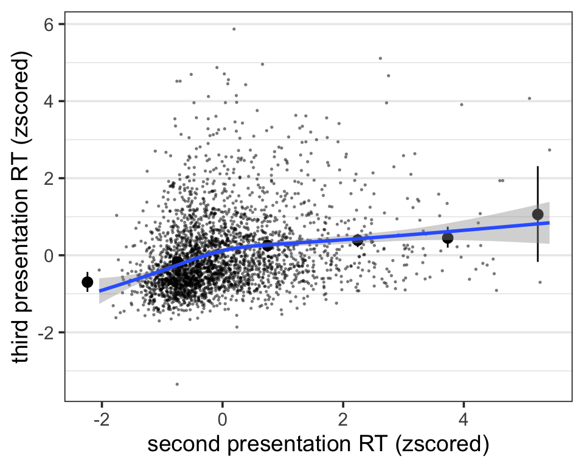

```r
X %>% ggplot(aes(rt_z2, rt_z3)) +
    geom_point(size=.3, alpha=.4) +
    stat_summary_bin(fun.data=mean_cl_boot, bins=5) +
    geom_smooth() +
    labs(x="second presentation RT (zscored)", y="third presentation RT (zscored)")
```

```r
X %>% lmer(rt_z3 ~ rt_z2 + (rt_z2 + 0|wid), data=.) %>% summ
```

| Fixed Effects | Fixed Effects Est. | Fixed Effects S.E. | Fixed Effects t val. | Fixed Effects d.f. | Fixed Effects p |
| --- | --- | --- | --- | --- | --- |
| (Intercept) | 0.000 | 0.018 | 0.000 | 2729.000 | 1.000 |
| rt_z2 | 0.256 | 0.021 | 12.288 | 69.000 | 0.000 |

p values calculated using Satterthwaite d.f.

Note: linear models don’t have random intercepts because both the predictor and response are z-scored (random slopes only).